# Mise en oeuvre de la centrale de pêche 937c

## Présentation

Le système d’“aide à la navigation” récupère des informations à partir d’une centrale de pêche (Humminbird 937c) sur laquelle est reliée une antenne GPS et un sondeur.

[figure not shown]

[figure not shown]

```
Un sondeur monofaisceau classique émet un signal acoustique vers le fond et analyse l'écho retour. Connaissant la vitesse de propagation du son dans l'eau et le temps entre l'émission du signal et la réception de l'écho du fond, le sondeur détermine la distance entre le sondeur et le fond par la relation : R = C.dt / 2.
```

La centrale de pêche communique en respectant le standard NMEA 0183 sur une liaison RS422. Cela nécessite d’installer un multiplexeur NMEA 0183 avec une liaison USB afin de relier l’ensemble au PC portable :

[figure not shown]

Le pilote de périphérique (*driver*) du Miniplex crée un **port COM virtuel** qui peut être ouvert comme tout autre port COM série.

Ici, le port série se paramètre avec les propriétés du standard NMEA 0183 :

- débit : 4800 bits/s ou 9600 bits/s
- format des données : 8 bits
- nombre de bits de stop : 1 bit
- pas de parité
- aucun contrôle de flux

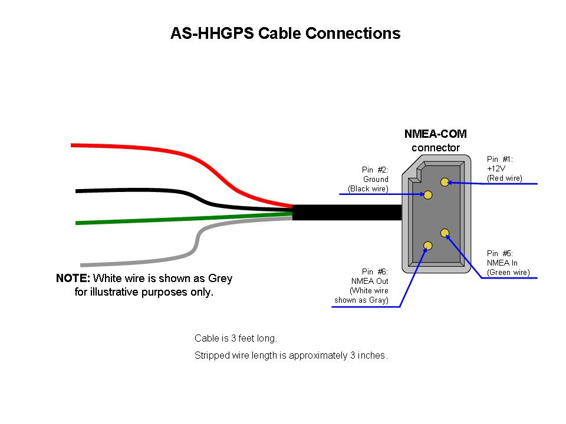

```
La norme NMEA 0183 est une spécification pour la communication entre équipements marins, dont les équipements GPS. Elle est définie et contrôlée par la National Marine Electronics Association (NMEA), association américaine de fabricants d'appareils électroniques maritimes. La norme 0183 utilise une simple communication série pour transmettre une "phrase" à un ou plusieurs écoutants. Une trame NMEA 0183 utilise tous les caractères ASCII. Le type d'équipement est défini par les deux caractères qui suivent le $ et le type de trame est défini par les caractères suivants jusqu'à la virgule. Par exemple :  $GPGGA,064036.289,4836.5375,N,00740.9373,E,1,04,3.2,200.2,M,,,,0000*0E est une trame GPS de type GGA qui fournit des données de géolocalisation. Chaque trame a sa syntaxe propre, mais selon le cas elles peuvent ou doivent se terminer, après le *, par une somme de contrôle (checksum) qui permet de vérifier que la trame n'a pas été endommagée avant sa réception.
```

La centrale de pêche fournit à l’application la possibilité de lire la hauteur de fond pour assurer la sécurité de la navigation.

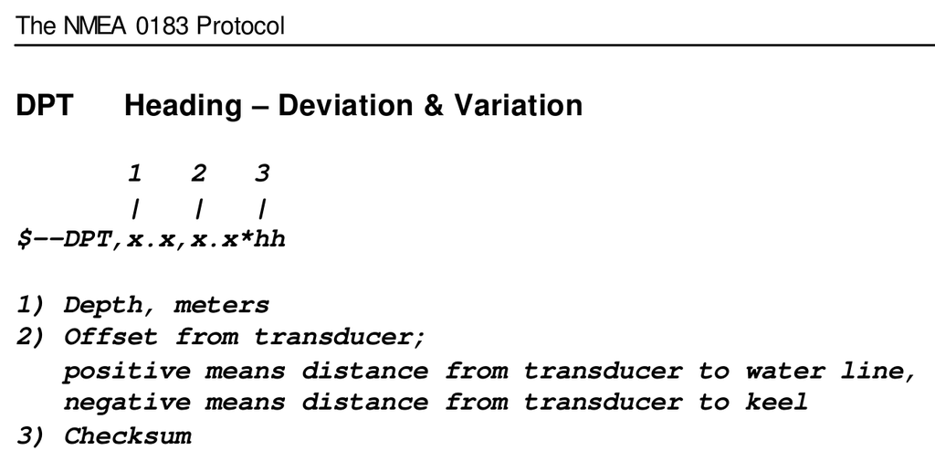

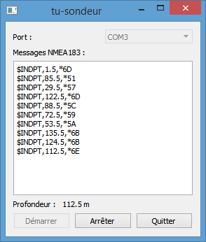

Documentations : Protocol-NMEA-0183.pdf, Miniplex-USB.pdf, 917c-fr.pdf et GPS.pdf

## Travail demandé

1. En utilisant le logiciel TeraTerm, capturer les messages NMEA 0183 émis par la centrale de pêche.
2. Décoder un message DPT et déterminer la hauteur de fond renvoyé par la centrale.

Soit la capture suivante :

```
$GPGGA,111841.000,4405.1958,N,00457.8627,E,1,05,2.54,44.9,M,49.1,M,,*5E
$GPGSA,A,3,06,20,07,10,09,,,,,,,,2.71,2.54,0.95*02
$GPRMC,111841.000,A,4405.1958,N,00457.8627,E,0.76,225.51,240115,,,A*6C
$GPVTG,225.51,T,,M,0.76,N,1.40,K,A*38
...
$GPGSV,3,1,12,20,79,354,16,23,74,056,,09,71,233,16,06,54,298,25*79
```

Lien : Conversions coordonnees GPS

3. À partir de la documentation sur le protocole NMEA 0183, décoder la phrase RMC.
4. Convertir la longitude et latitude du format GPS en degré décimal dd.dddd.
5. Puis convertir de degré décimal dd.dddd en Degres Minutes decimal-Seconds (D° M’ S’’).

Retour au sommaire